# 半月板的解剖

胡哥小腱匠

2019-08-04

# **半月板知识普及系列** —— 第一章：半月板的解剖学

#### 作者： 胡叶君

曾经，半月板被认为是“腿部肌肉起点的无功能残留物 functionless remnants of leg muscle origin”（Bland Sutton J.The ligaments of the knee joint// Ligaments,Bland Sutton J.Their Nature and Morphology,2th ed.London: Lewis,1987:32-38.），这种观点延续了很长时间，直到近现代，随着研究的不断深入，半月板的重要功能逐渐展现而被改变。

在现代化的生活中，代步车逐渐普及，使得人们的日常活动量大大降低。据说冷兵器时代人平均每天步行三万步，现在的人平均不到一万步，懒的人恐怕几千步都走不了。

这直接导致的结果是运动系统的退化，表现在膝关节就是半月板、软骨、肌肉的普遍退化，肌肉力量下降导致保护性差，半月板退化表现为其柔韧性差，容易撕裂、损伤。

半月板损伤目前是膝关节运动损伤中第一位的。

下面我们就来认识一下半月板。

```
本章内容：
1：半月板的解剖
2：半月板的形态
3：半月板的血供
```

# 部位

- 膝关节半月板位于股骨髁与胫骨面之间，内外侧各一个。
- 内侧半月板覆盖60%左右的股胫关节面，而外侧半月板能覆盖90%的关节面。

[figure not shown]

# 形态

- 半月板大体呈月牙形，内侧半月板为“C”型，外侧半月板为“O”型。

[figure not shown]

- 从半月板的冠状切面看呈近似三角形，表现为周缘厚，内缘薄，上缘稍呈凹形，与股骨髁的凸起相吻合，下缘扁平，与胫骨平台相接。

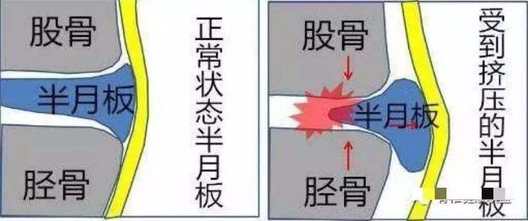

# 主要血供

半月板的血供来自于膝下内侧动脉、膝下外侧动脉、膝中动脉、膝上内侧动脉（膝上外侧动脉不参与半月板血供）、膝降动脉、膝后内侧动脉和膝后外侧动脉，以上这些动脉形成紧绕半月板的周围动脉环。

[figure not shown]

### 膝下内侧动脉

自后向前经胫骨内侧缘与腘肌上缘的筋膜内走向前侧，至胫骨内侧缘前下方沿内侧半月板外周走行。

[figure not shown]

### 膝下外侧动脉

在距腓骨小头顶点上方，经腓侧副韧带深面，紧贴外侧半月板外周向前走行。

[figure not shown]

### 膝中动脉

膝中动脉是囊内韧带最重要的血液供应来源，也是半月板前、后角的主要血供来源之一，穿过腘斜韧带进入囊内韧带、滑膜皱襞和半月板前、后角。

[figure not shown]

# 总结

半月板损伤作为临床常见疾病，其解剖部位、形态结构及血运类型与半月板的功能和损伤类型密切相关，本章对后续半月板功能和损伤类型的分类提供了基础知识。